# TAU 20 Middle_0_0.1_8

## Sample=1zlb-A:197:CA-A:197:N-A:197:C

| pdb_code | central atom | ca density | parallel atom | pa density | planar atom | pl density |
| --- | --- | --- | --- | --- | --- | --- |
| 1zlb | [25.58, 7.23, 50.31] | 21.5697 | [25.21, 6.56, 49.04] | 27.4151 | [26.5, 8.41, 50.2] | 22.6032 |

Sliced x-wise

Sliced y-wise

Sliced z-wise

40/81

40/81

40/81

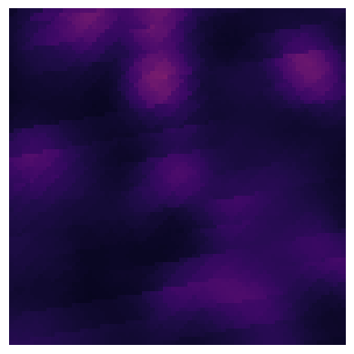

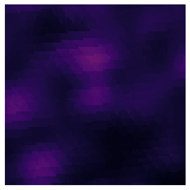

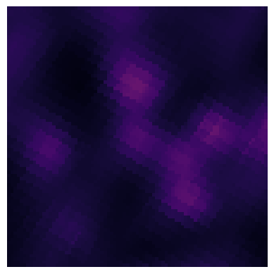

## Sample=2bog-A:78:CA-A:78:N-A:78:C

| pdb_code | central atom | ca density | parallel atom | pa density | planar atom | pl density |
| --- | --- | --- | --- | --- | --- | --- |
| 2bog | [-4.42, -1.77, 21.03] | 16.6955 | [-3.89, -0.6, 21.73] | 17.3291 | [-3.51, -2.4, 19.98] | 19.1225 |

Sliced x-wise

Sliced y-wise

Sliced z-wise

40/81

40/81

40/81

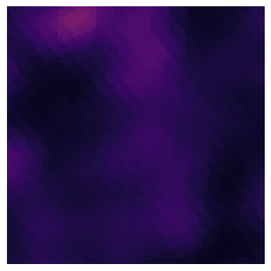

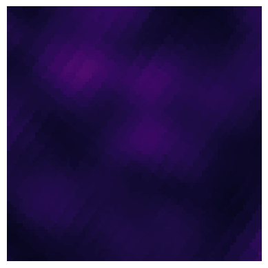

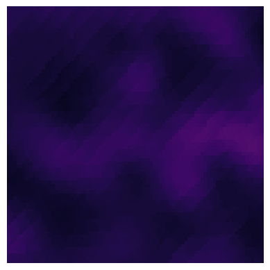

## Sample=1w6s-X:2:CA-X:2:N-X:2:C

| pdb_code | central atom | ca density | parallel atom | pa density | planar atom | pl density |
| --- | --- | --- | --- | --- | --- | --- |
| 1w6s | [-5.85, 24.27, -20.87] | 32.1053 | [-7.2, 23.85, -21.34] | 40.6688 | [-5.75, 24.69, -19.41] | 36.0164 |

Sliced x-wise

Sliced y-wise

Sliced z-wise

40/81

40/81

40/81

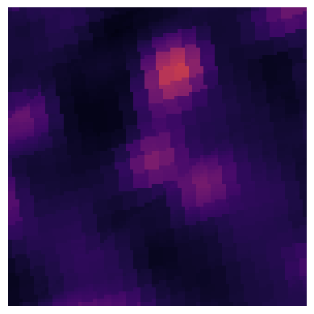

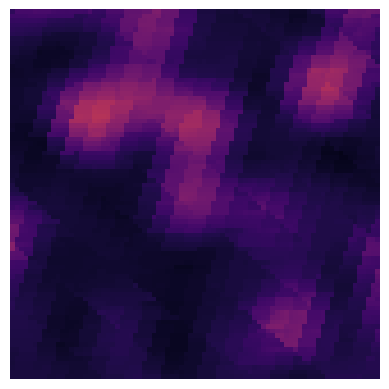

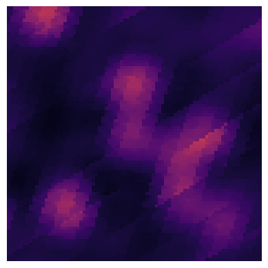

## Sample=3zn4-A:330:CA-A:330:N-A:330:C

| pdb_code | central atom | ca density | parallel atom | pa density | planar atom | pl density |
| --- | --- | --- | --- | --- | --- | --- |
| 3zn4 | [26.86, -24.77, -6.39] | 37.5819 | [26.21, -26.09, -6.49] | 34.8857 | [27.78, -24.56, -5.17] | 36.3402 |

Sliced x-wise

Sliced y-wise

Sliced z-wise

40/81

40/81

40/81

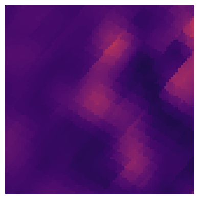

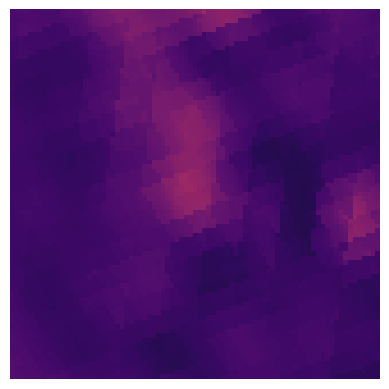

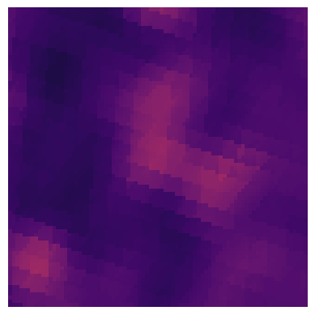

## Sample=4cj0-A:70:CA-A:70:N-A:70:C

| pdb_code | central atom | ca density | parallel atom | pa density | planar atom | pl density |
| --- | --- | --- | --- | --- | --- | --- |
| 4cj0 | [13.38, 56.15, 18.83] | 15.7725 | [14.74, 55.83, 18.42] | 19.1372 | [12.27, 55.21, 18.33] | 16.4371 |

Sliced x-wise

Sliced y-wise

Sliced z-wise

40/81

40/81

40/81

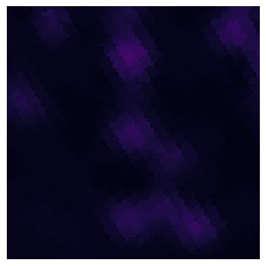

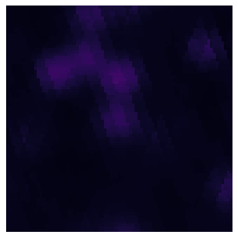

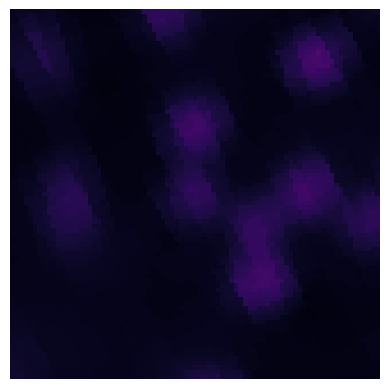

## Sample=2pgn-A:167:CA-A:167:N-A:167:C

| pdb_code | central atom | ca density | parallel atom | pa density | planar atom | pl density |
| --- | --- | --- | --- | --- | --- | --- |
| 2pgn | [48.31, 66.81, 8.76] | 27.8649 | [47.38, 65.66, 8.79] | 30.3023 | [48.81, 67.32, 10.13] | 26.1305 |

Sliced x-wise

Sliced y-wise

Sliced z-wise

40/81

40/81

40/81

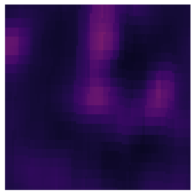

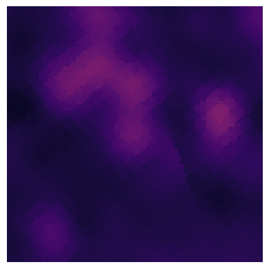

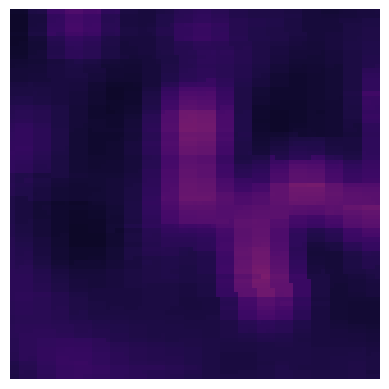

## Sample=4bat-A:543:CA-A:543:N-A:543:C

| pdb_code | central atom | ca density | parallel atom | pa density | planar atom | pl density |
| --- | --- | --- | --- | --- | --- | --- |
| 4bat | [2.54, 47.69, 28.76] | 30.2262 | [3.34, 48.6, 27.95] | 36.0606 | [3.29, 46.57, 29.45] | 28.7194 |

Sliced x-wise

Sliced y-wise

Sliced z-wise

40/81

40/81

40/81

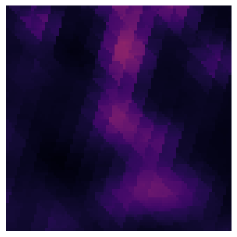

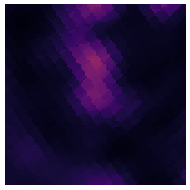

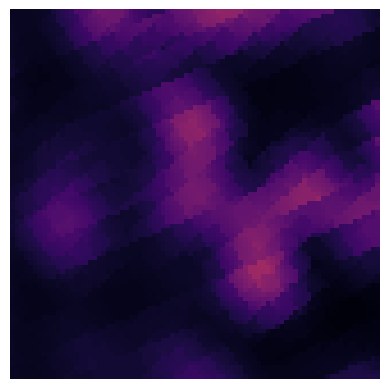

## Sample=1jo8-A:273:CA-A:273:N-A:273:C

| pdb_code | central atom | ca density | parallel atom | pa density | planar atom | pl density |
| --- | --- | --- | --- | --- | --- | --- |
| 1jo8 | [5.37, 27.14, 0.48] | 55.732 | [4.39, 28.2, 0.26] | 65.1964 | [4.96, 26.03, 1.42] | 53.8901 |

Sliced x-wise

Sliced y-wise

Sliced z-wise

40/81

40/81

40/81

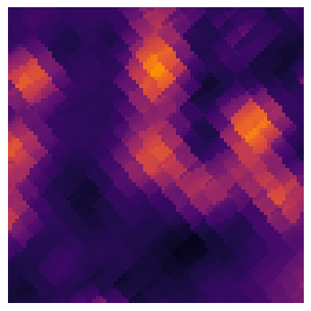

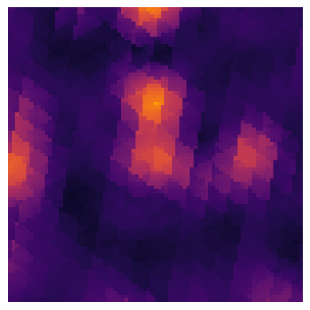

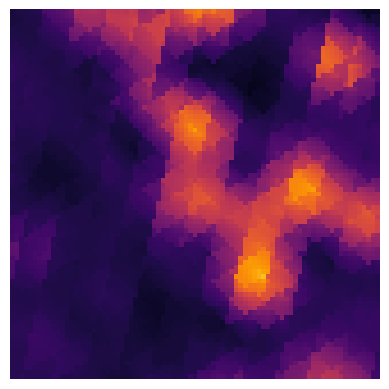

## Sample=3tm8-A:56:CA-A:56:N-A:56:C

| pdb_code | central atom | ca density | parallel atom | pa density | planar atom | pl density |
| --- | --- | --- | --- | --- | --- | --- |
| 3tm8 | [-6.8, -22.9, -29.06] | 16.2531 | [-7.98, -23.13, -29.9] | 19.5623 | [-5.48, -23.51, -29.56] | 16.652 |

Sliced x-wise

Sliced y-wise

Sliced z-wise

40/81

40/81

40/81

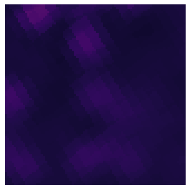

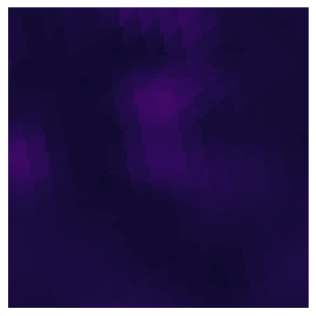

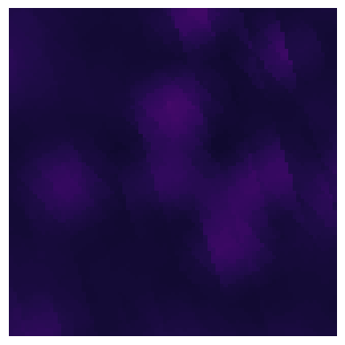

## Sample=4ldn-A:43:CA-A:43:N-A:43:C

| pdb_code | central atom | ca density | parallel atom | pa density | planar atom | pl density |
| --- | --- | --- | --- | --- | --- | --- |
| 4ldn | [26.23, 3.67, 43.12] | 18.3032 | [25.03, 4.14, 43.89] | 21.0091 | [26.77, 4.62, 42.04] | 20.4087 |

Sliced x-wise

Sliced y-wise

Sliced z-wise

40/81

40/81

40/81

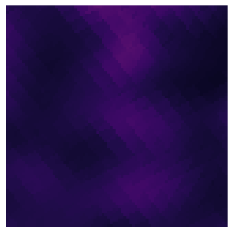

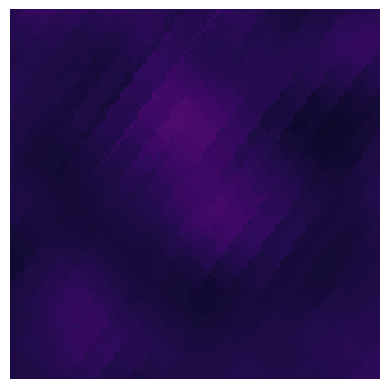

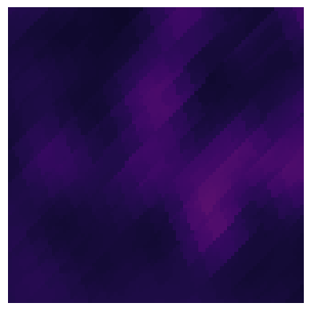

## Sample=4q68-A:27:CA-A:27:N-A:27:C

| pdb_code | central atom | ca density | parallel atom | pa density | planar atom | pl density |
| --- | --- | --- | --- | --- | --- | --- |
| 4q68 | [36.51, -7.08, 14.7] | 13.3592 | [36.69, -6.43, 13.4] | 18.371 | [35.32, -8.01, 14.82] | 12.2421 |

Sliced x-wise

Sliced y-wise

Sliced z-wise

40/81

40/81

40/81

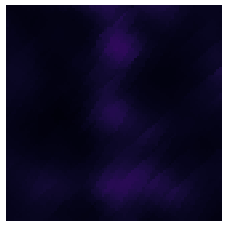

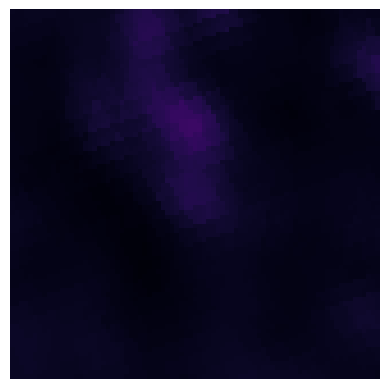

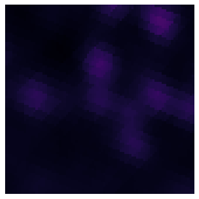

## Sample=2r14-A:98:CA-A:98:N-A:98:C

| pdb_code | central atom | ca density | parallel atom | pa density | planar atom | pl density |
| --- | --- | --- | --- | --- | --- | --- |
| 2r14 | [6.63, 69.3, 18.17] | 24.7626 | [5.67, 68.26, 18.56] | 39.5497 | [8.1, 69.07, 18.57] | 33.4465 |

Sliced x-wise

Sliced y-wise

Sliced z-wise

40/81

40/81

40/81

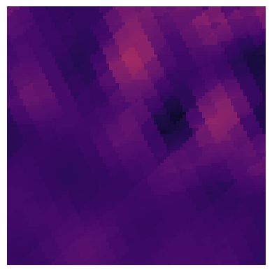

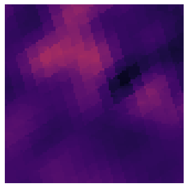

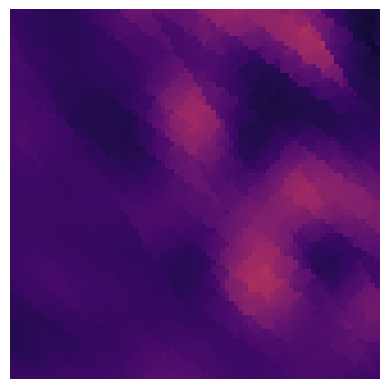

## Sample=3cnj-A:248:CA-A:248:N-A:248:C

| pdb_code | central atom | ca density | parallel atom | pa density | planar atom | pl density |
| --- | --- | --- | --- | --- | --- | --- |
| 3cnj | [42.78, -5.49, 34.76] | 23.4316 | [43.16, -6.47, 33.74] | 30.0882 | [42.03, -6.01, 35.94] | 23.1294 |

Sliced x-wise

Sliced y-wise

Sliced z-wise

40/81

40/81

40/81

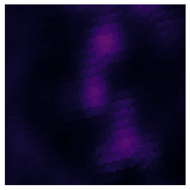

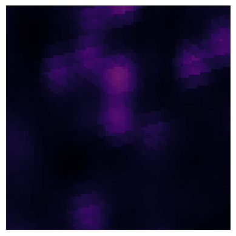

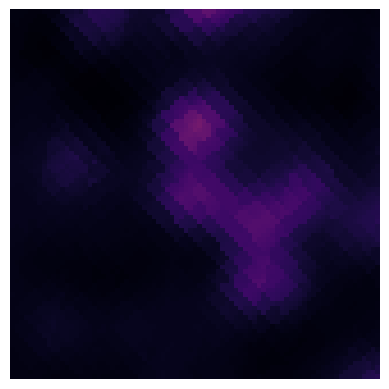

## Sample=4lpq-A:38:CA-A:38:N-A:38:C

| pdb_code | central atom | ca density | parallel atom | pa density | planar atom | pl density |
| --- | --- | --- | --- | --- | --- | --- |
| 4lpq | [15.3, -14.1, 49.92] | 23.5669 | [14.83, -12.74, 49.72] | 27.1716 | [16.79, -14.28, 50.14] | 23.5492 |

Sliced x-wise

Sliced y-wise

Sliced z-wise

40/81

40/81

40/81

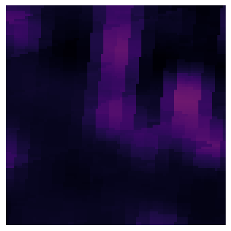

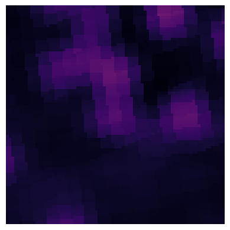

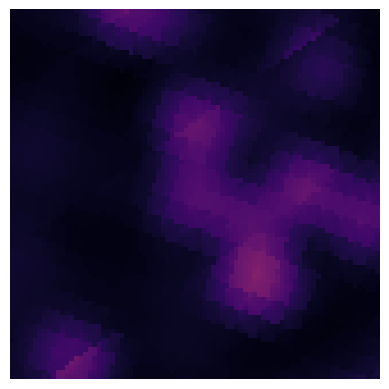

## Sample=1nuy-A:505:CA-A:505:N-A:505:C

| pdb_code | central atom | ca density | parallel atom | pa density | planar atom | pl density |
| --- | --- | --- | --- | --- | --- | --- |
| 1nuy | [2.3, 29.04, 31.88] | 26.8524 | [1.79, 27.76, 31.37] | 37.373 | [3.77, 29.06, 32.29] | 29.4309 |

Sliced x-wise

Sliced y-wise

Sliced z-wise

40/81

40/81

40/81

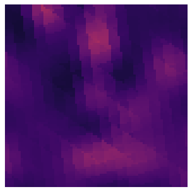

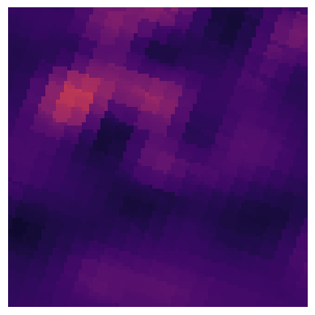

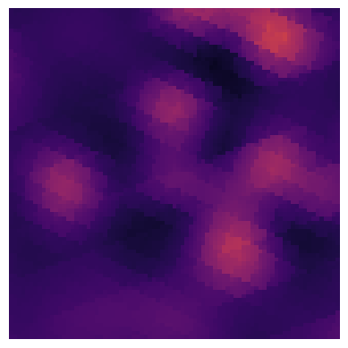

## Sample=3qhb-A:213:CA-A:213:N-A:213:C

| pdb_code | central atom | ca density | parallel atom | pa density | planar atom | pl density |
| --- | --- | --- | --- | --- | --- | --- |
| 3qhb | [22.66, 24.86, -7.54] | 12.4893 | [22.89, 25.17, -6.14] | 13.2538 | [21.9, 23.57, -7.82] | 14.2679 |

Sliced x-wise

Sliced y-wise

Sliced z-wise

40/81

40/81

40/81

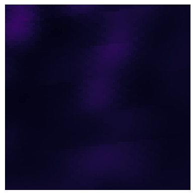

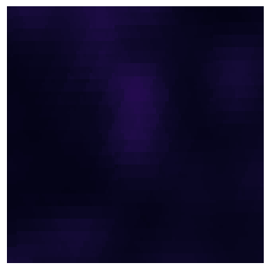

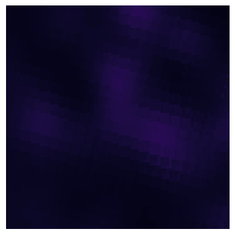

## Sample=3drf-A:180:CA-A:180:N-A:180:C

| pdb_code | central atom | ca density | parallel atom | pa density | planar atom | pl density |
| --- | --- | --- | --- | --- | --- | --- |
| 3drf | [4.2, 66.99, 41.69] | 28.276 | [5.67, 66.76, 41.66] | 36.6477 | [3.33, 65.79, 41.33] | 29.0617 |

Sliced x-wise

Sliced y-wise

Sliced z-wise

40/81

40/81

40/81

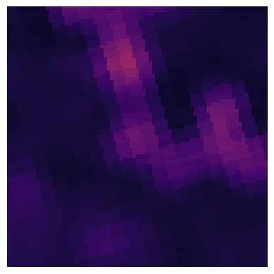

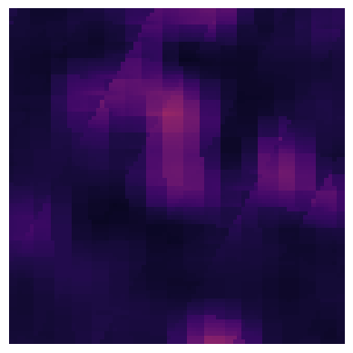

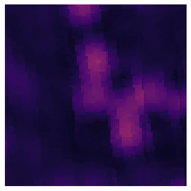

## Sum of all densities

Sliced x-wise

Sliced y-wise

Sliced z-wise

40/81

40/81

40/81

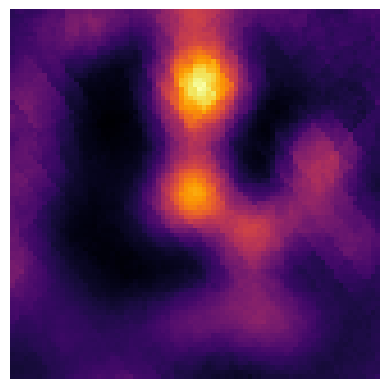

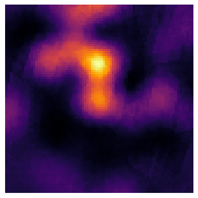

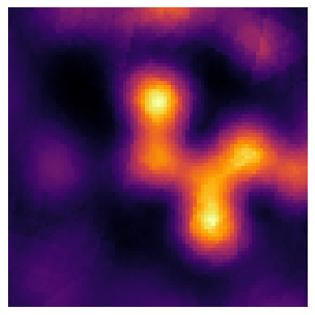

## Log-sum of all densities transformed values

Sliced x-wise

Sliced y-wise

Sliced z-wise

40/81

40/81

40/81

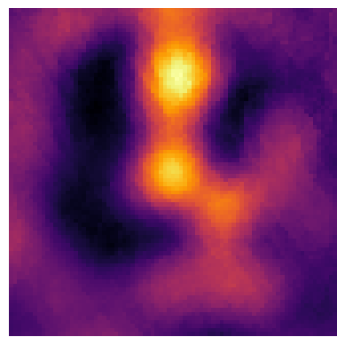

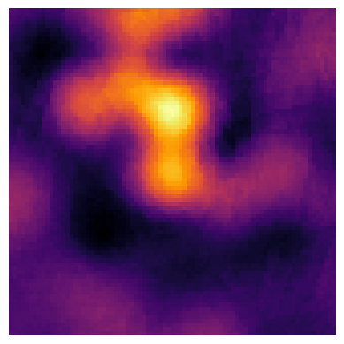

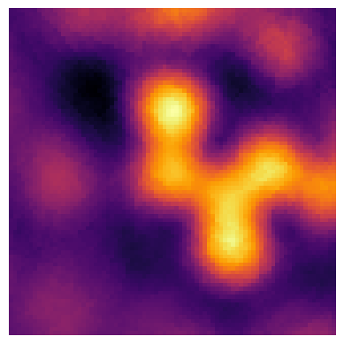